# June_Progress_update

## June update

#### Regular hosts from CICIDS-data

For all discussed hosts, I sorted all packets into an incoming stream (packets with destination IP of the host), and outgoing stream (source IP is the host), once with all packets and once when packets are sampled at a 1:1000 rate (i.e. 99,9% of all packets are thrown away to simulate the view of an ISP). I chose this way of grouping streams instead of incoming and outgiong connections since in the sampled view, we would not be able to identify which packet belongs to an incoming connection or not. It is thinkable that we could group streams in a smarter way when looking at the destination and source port, which might reveal more regarding the direction of the stream and the functionality of the proxy. However, this would require some additional assumptions about the proxy, which we do not want to make at this moment.

I binned the packets into 3 minute interval bins, and plotted the incoming stream and outgoing stream against each other for both counted number of packets, and number of bytes in each bin. I also calculated the Pearson correlation between the two streams due to our hypothesis that the incoming and outgoing stream should show significantly more correlation than regular hosts.

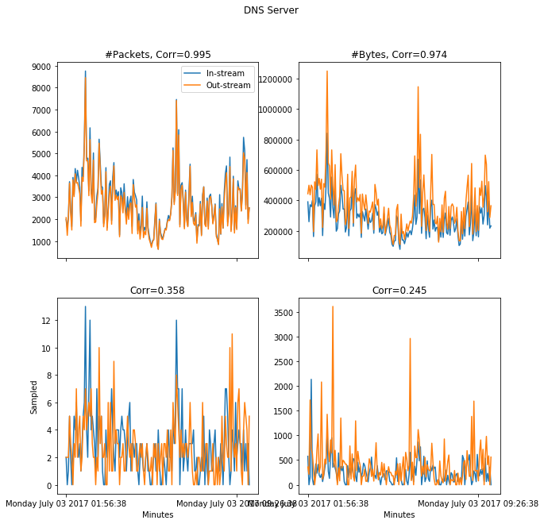

Above are plots for a DNS server, which shows very heavy correlation for both streams, which is to be expected from its functionality. Interestingly, when looking at the sampled view, the correlation is not measurable in such a strong way.

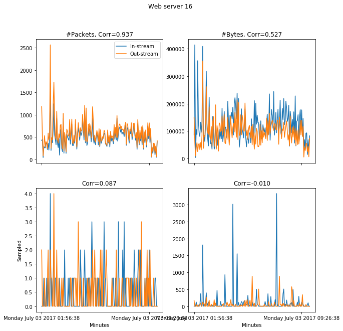

Above are plots for a Web server. We see very strong correlation in the packet number stream, but not as much in the byte stream. Overall, due to the nature of the TCP-packet-acknowledgement system, I would expect the packet number stream to be strongly correlated for every host using predominantly TCP. In the sampled view, we measure almost no correlation for either metric, however this is likely due to the fact that the server is not very active and is not receiving enough packets for the correlation signal to persist in the sampled view.

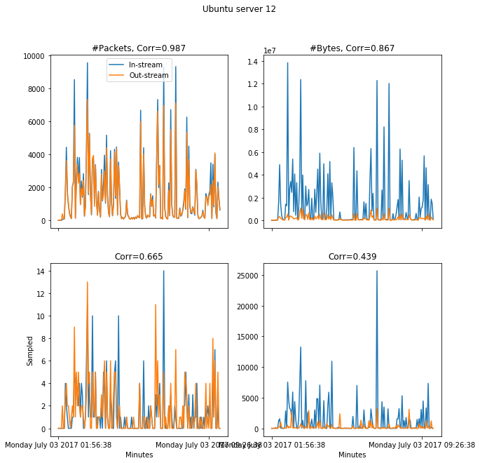

This server sees more activity and also more correlation in the byte stream, which is however still clearly below the packet stream correlation. For the sampled view, we measure moderate correlation of both metrics, since the activity rate is higher.

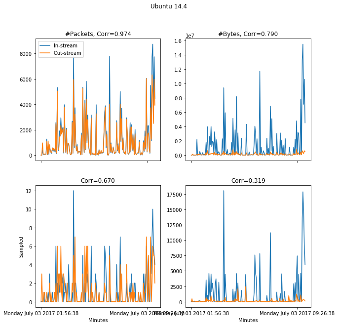

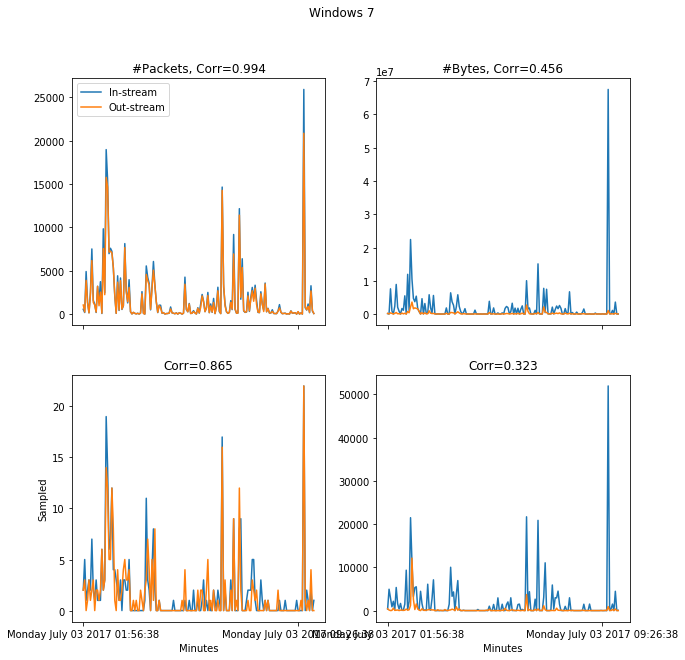

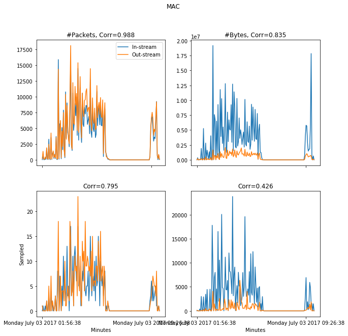

Plots above are now for personal computers, but show a very similar picture to the server above regarding byte stream correlation and visible correlation under sampling.

## Proxy data

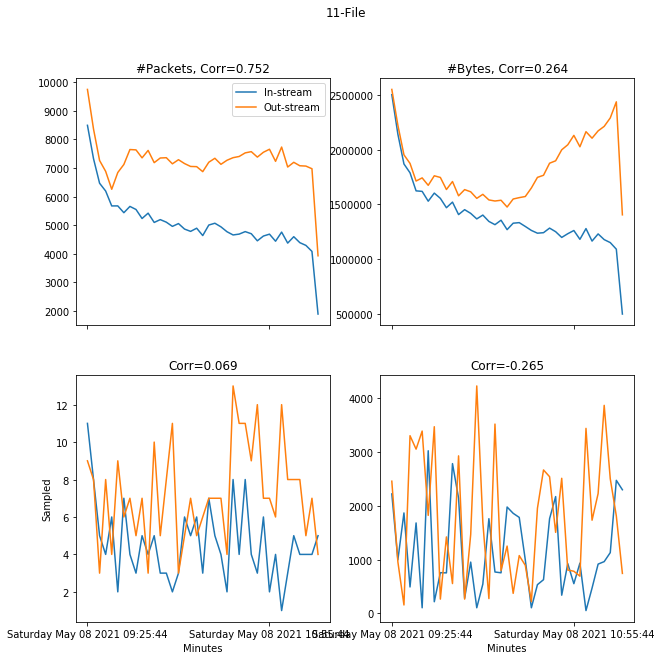

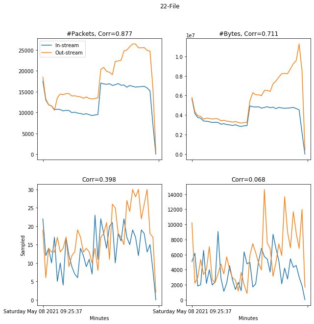

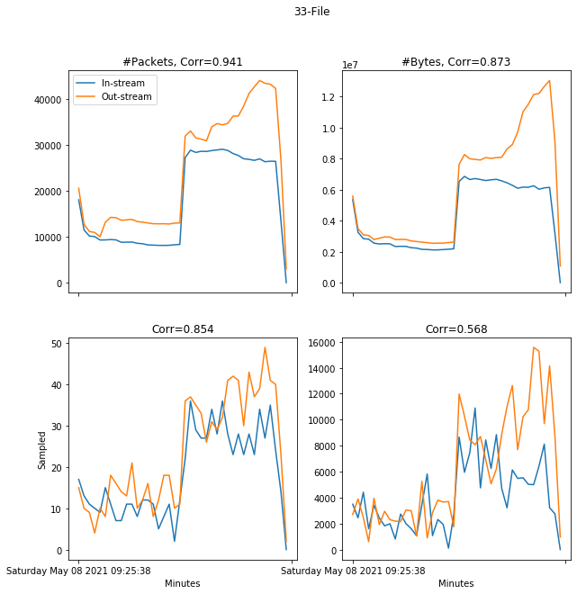

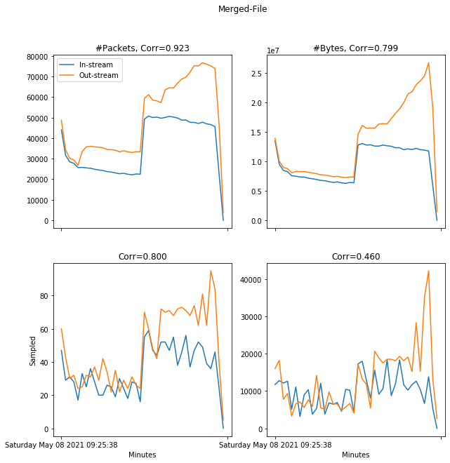

The plots above now show the same metrics for our proxy in increasing activity (11-file=low activity, 33-file=high activity, plus the merge of all three files). Three things strike me immediately:

- The byte stream in the non-sampled view is less correlated than expected, and less correlated than some of the benign hosts. At the current stage, it would therefore not be suitable as a measure to identify proxies. This is a bit puzzling, since for a theoretical proxy, we would expect almost 100% correlation (all incoming content also goes out). I believe this is due the size of the files we transfer being too small compared to a proxy one would think of that continuously transfers large amounts of data. When the size of transferred data is too small, the byte stream might get more dominated from TCP-overhead such as connection establishment and ack-packets sent.
- We do not see as many activity spikes as for the benign hosts. This very likely also decreases the measured correlation as the signal is mostly constant and movements are more governed by random fluctuations which decrease the measured correlation.
- We only start to measure correlation between the streams in the sampled view for the file with the most activity (and the merged file). This is an important thing to consider as we would not be able to detect proxies with low activity when looking at sampled packets. We should get some information about the amount of traffic we would expect on a malicious proxy.